# Testing BISG Race Imputation Against Known Race

BISG checked against the truth, on forty-six thousand Georgia voters

Democracy’s Data

Last updated September 13, 2026 at 10:53a EDT

Courts are told every year how many Black voters live in a district, and nobody counted them. Voter files do not record race, so the number is manufactured by a method: **Bayesian Improved Surname Geocoding**, or BISG, which multiplies what a surname implies about a person by what their neighbourhood implies (the surnames brief works the arithmetic by hand). Elliott and colleagues (2009) built it for health records;[^1] Imai and Khanna (2016) brought it to voter files.[^2] It is the standard evidence in vote-dilution cases under Section 2 of the Voting Rights Act, the provision that forbids election rules giving minority voters less opportunity than others to elect candidates of their choice,[^3] and in federal lending-discrimination work.[^4] How good is the guess?

Almost everywhere, that question cannot be asked, because an inference is an inference when the answer is not written down. Georgia writes it down. Race appears on the voter registration form, collected, as the federal registration form puts it, “in order to administer the Federal Voting Rights Act.”[^5] So in one Georgia county there are 45,984 people whose race a widely used method is guessing, and whose race is already on file.

The question sounds like it has one answer. It has five, and they disagree with each other by 90 points.

## The test

The test joins three files, none of which was built to meet the others. The first is a Houston County, Georgia voter registration extract, carrying each voter’s surname, the race they reported and the census block they live in. It is working data from the county’s 2026 redistricting matter, and it is not published: a Georgia voter file is ordered from the state (https://sos.ga.gov/page/order-voter-registration-lists-and-files), cut on one day and never regenerated. The second file is the 2020 Census count of who lives on each of the county’s blocks. The third is the Census Bureau’s *Frequently Occurring Surnames* table from the 2020 Census — every surname held by about a hundred or more people, with the race shares of its holders — downloadable at https://www2.census.gov/topics/genealogy/2020surnames/, and the same copy the surnames brief uses, so the two briefs cannot disagree about it.

These files can answer the question because one of them contains the answer. A small number of states put a race question on the registration form, most of them once subject to federal supervision of their election law. Nobody collected that column to grade a statistical method, which is what makes it a fair answer key.

It is also the deepest problem in this literature. **An inference can only be graded where the answer is recorded, and the answer is only recorded where the inference is unnecessary.** Every published accuracy figure for BISG comes from a place that did not need it.

Two joins have to hold before anything can be scored. Join Keys and Crosswalks is the reading on what a join key is and how one fails silently. It also covers the repair when two files carry different keys: a crosswalk, a table that translates one set of identifiers into another.

## The data

Every number below comes from running BISG here, on every voter, and comparing each answer with the race that voter reported. The surname’s race shares, the block’s, the two rules for when one of them fails, and the scoring are all recomputed on this page; nothing is copied from a published accuracy figure.

The join runs on two keys and both are strings of text. The **surname** joins a voter to the Census surname list. The **fifteen-character census block identifier**, `GEOID20`, joins a voter to the block table — a GEOID is the Bureau’s code for any piece of its geography, and a block’s is the state, county, tract and block numbers run together — and it arrived already filled in. Somebody matched street addresses to blocks before this brief existed, and every address that failed was settled by a rule no column records. Geography is half of what the method uses, so part of what gets graded below is that match.

Three cleaning decisions got 53 columns down to three, and each one changes what can be claimed.

**Rows whose answer key was written by the method being graded are dropped first.** 11,168 of the 155,756 records carry a flag saying the voter left the race question blank and somebody filled it in by running BISG. Scored against those rows the method looks superb, and nothing in the numbers would give the circularity away.

**A further 854 voters reported a race the five-category scheme has no box for, or none at all.** They are dropped too, which is not a neutral act: the method is now graded only on people who fit the categories it predicts.

**The identifiers go on purpose.** The registration number joins the two state files and is discarded as soon as the join is done, so the committed table cannot be linked back to a person. It cannot be audited against its source either.

What survives is 49,771 voters across 2,130 blocks, in three columns: `surname`, `race` as the voter reported it, and `GEOID20`. The census side is aggregated to the same 3,269 blocks, one column of residents per group. One more thing happens before scoring:

| Quantity | Value |
| --- | --- |
| Voters in the file | 49,771 |
| Whose surname appears in the Census surname list | 45,984 (92.4%) |
| Whose surname does not | 3,787 |
| Voters the method is scored on | 45,984 |

3,787 voters, 7.6% of them, hold a surname the Census list does not carry, because too few Americans shared it in 2020 for the Bureau to publish it. The method has no opinion about them, so they appear in no figure below. Who they are turns out to matter.

Here is one case, worked the way the method works it. Take the commonest surname in the county’s file, Williams, and the census block where the most Williamses are registered. (The block is not named here; nothing from the voter file is reproduced except a tally.)

| Group | WILLIAMS, by name (%) | Living on the block | The block (%) | The county (%) | Block ÷ county | Name × ratio | Posterior (%) |
| --- | --- | --- | --- | --- | --- | --- | --- |
| white | 46.2 | 198 | 30.0 | 53.9 | 0.56 | 25.7 | 20.8 |
| Black | 48.7 | 445 | 67.4 | 35.3 | 1.91 | 92.9 | 75.3 |
| Hispanic | 3.7 | 7 | 1.1 | 7.4 | 0.14 | 0.5 | 0.4 |
| Asian | 0.6 | 3 | 0.5 | 3.1 | 0.14 | 0.1 | 0.1 |
| Am. Indian | 0.8 | 7 | 1.1 | 0.2 | 5.00 | 4.1 | 3.3 |

The surname table says a Williams is 48.7% Black and 46.2% white, so the name alone settles nothing. The 2020 count found 660 people living on the block, 445 of them Black and 198 white. That makes the block 67.4% Black against 35.3% for the county as a whole, 1.91 times the county share, and 30.0% white against 53.9%, 0.56 times. Multiply each group’s name share by its ratio, add the five products, and each product’s share of the total is the **posterior**, the probability once the block has been taken into account: 75.3% Black, 20.8% white. The method’s guess is Black. On the answer key, 11 of the 11 registered voters named Williams on that block reported Black, and across the county’s 699 Williamses 72.5% did. That is one case going right. The rest of this brief counts how often it does.

> **Before you read on, write down three numbers.** BISG scores 67.3% overall on these voters. First: what share of *white* voters do you think it gets right? Second: what share of *Black* voters? Third, and this is the one that matters — **what would a method score if it simply guessed “white” for every voter in the county**, with no surname, no geography and no model at all?

## What it says about democracy

Start with the third number, because it is free. **Guessing “white” for everybody scores 51.5%**, since 51.5% of these voters are white. Most people put that floor near a fifth, on the intuition that a five-category problem gives a blind method one chance in five. The surname alone scores 61.3%, and BISG with the block scores 67.3%.

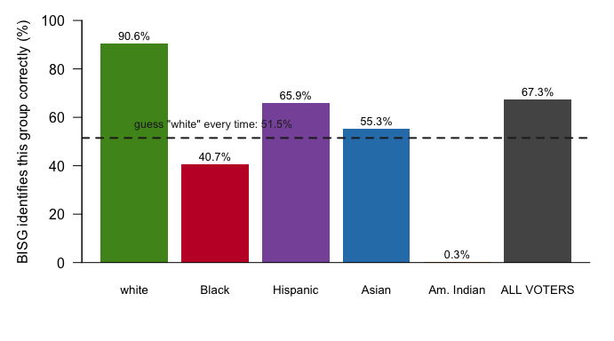

The dashed line is free: it is what a method with no method scores. 2 of the five groups sit below it, and so would the whole electorate if it were not 51.5% white. Hover a bar for the group size.

**Figure 1. Every accuracy in this brief, against the number available for free.** One bar per group fits this question, because the question is a comparison against a fixed reference. The bars are how often BISG identifies each group correctly, with the whole scored electorate on the right, and the dashed line at 51.5% is what a method with no method collects. 2 of the five groups sit below it, and so would the overall bar if the county were not 51.5% white.

Read down the column rather than across the bottom:

| The voter actually is | How many | Surname only | Surname + block | Change |
| --- | --- | --- | --- | --- |
| white | 23,668 | 94.5% | 90.6% | -3.9 |
| Black | 16,841 | 16.9% | 40.7% | +23.8 |
| Hispanic | 2,319 | 71.4% | 65.9% | -5.5 |
| Asian | 2,038 | 64.2% | 55.3% | -8.8 |
| Am. Indian | 1,118 | 0.2% | 0.3% | +0.1 |

**The overall figure is not a summary of how the method performs. It is a summary of who lives in Houston County.** On an unbalanced problem, overall accuracy mostly reports the balance.

Adding the census block is not a free improvement either. It is a redistribution. Black voters gain +23.8 points, from 16.9% to 40.7%, because Black residents of this county are geographically concentrated and the block genuinely carries information about them. Asian voters lose 8.8 points, Hispanic voters 5.5, white voters 3.9. Those populations are spread thinly, so no block is distinctively Asian or Hispanic, and the geographic term drags the estimate toward the local majority. One group gained and three lost, while the overall figure moved +6.0 points and reported none of it.

Accuracy asks whether the winning label was right. Ask instead how much probability the model put on the answer that turned out to be correct — a question of **calibration**, whether a model that says “70%” is right about seven times in ten — and the per-person picture changes.

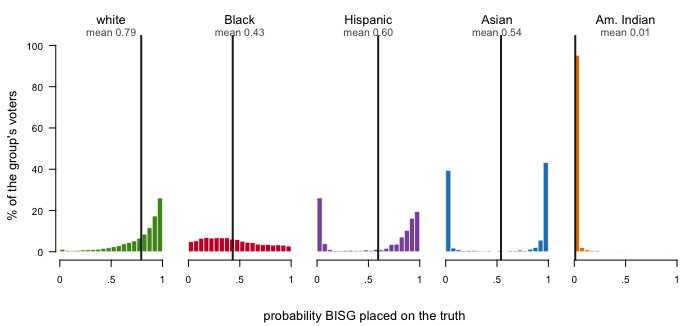

**Figure 2. How much probability the model placed on the answer that was correct.** One panel per group on a common scale, each bar a five-point slice of probability, with the vertical rule at that group’s mean. White voters pile against the right-hand wall and Am. Indian voters against the left. The Black panel is the one to sit with: spread through the middle, at neither end.

| The voter actually is | Mean probability BISG placed on the truth | How often BISG’s top guess was right |
| --- | --- | --- |
| white | 0.79 | 90.6% |
| Black | 0.43 | 40.7% |
| Hispanic | 0.60 | 65.9% |
| Asian | 0.54 | 55.3% |
| Am. Indian | 0.01 | 0.3% |

For Black voters the model puts 0.43 on the truth. It is not confidently wrong; it is genuinely uncertain, and then the decision rule forces a hard guess anyway. Much of the information loss is in collapsing a probability into a label rather than in the model. For American Indian voters it puts 0.01 on the truth, and those 1,118 voters cannot be found by any threshold at all.

Being wrong is also not one thing. The errors go somewhere, and where they go is the rest of the table.

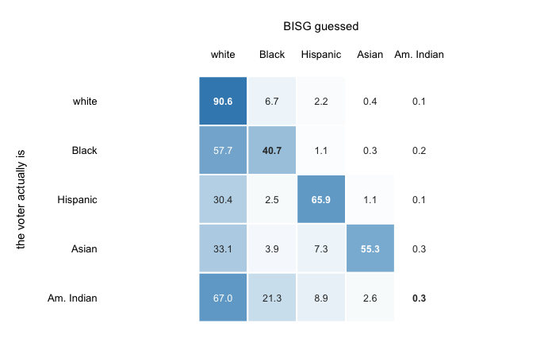

**Figure 3. Where the errors go.** Each row is a group of voters as they reported themselves, each column is what BISG guessed, and rows sum to 100%. The outlined diagonal is the accuracy column from the table above; everything off it is a specific mistake. The largest off-diagonal cell is 67.0% of Am. Indian voters labeled white, and 57.7% of Black voters are labeled white.

**The errors are not scattered.** They run one way, toward the group that is locally largest, which is exactly what multiplying by the block’s make-up does.

The same mechanism breaks the method outright for 394 people. 392 live in a block the census records as empty; for 2 more, surname and block contradict each other so flatly that every category multiplies to zero. Those are the two rules mentioned above: a voter on an empty block is scored with the county’s make-up in place of the block’s, and a voter whose name and block cancel out is scored on the name alone. Without them all 394 would have been labeled white, and 158 of them are Black.

Two checks cut the other way. Replace every block with the county’s make-up and the method scores 58.8% overall, **worse than no geography at all**, because one composition applied to everybody tilts every voter toward white. And on the 8,450 voters whose surname gives no group above 60%, adding the block is worth +16.1 points, more than twice what it gains on the full file. The method is strong exactly where the surname was weak.

**The number that should stay with you** is that with everything it has, BISG identifies Black voters correctly 40.7% of the time. It is wrong about them more often than it is right, in a county where 37% of these voters are Black, on the question Section 2 litigation turns on. That is not an argument for throwing the method out, because the alternative is no evidence and no way to prove vote dilution at all. It is an argument that an error rate this uneven belongs beside every estimate built on it, and it almost never is.

## What this brief cannot tell you

**It is one county.** Houston County, Georgia is about 51% white and moderately segregated, and nothing here says whether it is typical. The shape of these findings travels; the figures should not be quoted anywhere else.

**Whoever the surname list missed never entered the test.** The 3,787 unscored voters are 23.3% Hispanic against 6.4% among all registered voters, over-represented by a factor of about 3.6. So the Hispanic accuracy above was measured on Hispanic voters with common Hispanic surnames. Every figure here is conditional on the method having had an opinion in the first place.

**The answer key is itself a measurement.** The race on a registration form is one box, chosen by the voter, flattening the same people every categorical race question flattens. Any-part Black — counting as Black anyone who checked Black alone or together with another race — is the definition used throughout, following Voting Rights Act practice,[^6] and the stricter one would move every figure above. And these are registered voters rather than residents.

**And the validation comes from a biased set of places.** Checking BISG requires a state that records race on registration, which is a small group concentrated in the South and overlapping heavily with the states most often in Section 2 litigation. That is either reassuring, because it is where the method is used, or circular, for the same reason.

## What you should have learned

- On 45,984 people whose race is on record, BISG scores 67.3% overall, against a free floor of 51.5% for guessing “white” every time.
- That overall figure conceals the groups: 90.6% for white voters, 40.7% for Black, 0.3% for American Indian.
- Adding the census block is a redistribution, not an improvement: +23.8 points for Black voters, a loss for Asian, Hispanic and white voters, and +6.0 overall.
- The errors run one way, toward the locally largest group, which is what multiplying by a geographic prior does: 57.7% of Black voters are labeled white.
- 7.6% of voters were never scored, their surname being absent from the Census list, and they are 23.3% Hispanic against 6.4% of all registered voters.

## Extensions

None of these is answered above, and every one can be answered by sorting or grouping the tables the Sources section hands over.

- `houston_voters.csv` gives every voter a `surname`, a self-reported `race` and a `GEOID20`. Group by `race` and count. Which groups are large enough here to say anything about?
- Take a common surname from `census_surnames.csv` and find its holders in `houston_voters.csv`. Compare `pctwhite` and `pctblack` against what these voters reported.
- `houston_blocks.csv` gives each block’s residents by race. Sort on the five count columns to find the blocks with nobody in them. What should a method do when it lands on one?
- Pick a surname in `census_surnames.csv` whose shares are close to even, and work out the most confident BISG could possibly be about anyone carrying it.

Two stretch ideas point past the spreadsheet. North Carolina also records race on its registration form and publishes its file (https://www.ncsbe.gov/results-data/voter-registration-data); run the same comparison there and see whether the pattern holds. And find an expert report quoting a BISG accuracy figure, then check whether it reports by group or only overall.

## Sources

**Data**

- Houston County, Georgia voter registration with self-reported race and geocoded block assignment, from working data for the 2026 Houston County redistricting matter. **Rows whose race had been filled in by BISG were dropped first.** Georgia sells registration extracts to anyone who orders one. https://sos.ga.gov/page/order-voter-registration-lists-and-files
- Block population by race: 2020 Census P.L. 94-171 and Demographic and Housing Characteristics tables. https://www2.census.gov/programs-surveys/decennial/2020/data/01-Redistricting_File--PL_94-171/Georgia/ga2020.pl.zip
- Surname probabilities: U.S. Census Bureau, *Frequently Occurring Surnames from the 2020 Census*, giving the racial composition of the holders of every surname held by about a hundred or more Americans. https://www2.census.gov/topics/genealogy/2020surnames/. The 2010 edition the method’s authors worked from: https://www2.census.gov/topics/genealogy/2010surnames/names.zip
- Which states ask race on the registration form: U.S. Election Assistance Commission, *National Mail Voter Registration Form*, state instructions. https://www.eac.gov/sites/default/files/eac_assets/1/6/Federal_Voter_Registration_ENG.pdf

**Literature and cases**

- Elliott, M. N. et al. (2009). “Using the Census Bureau’s Surname List to Improve Estimates of Race/Ethnicity and Associated Disparities.” *Health Services and Outcomes Research Methodology* 9(2): 69–83. https://doi.org/10.1007/s10742-009-0047-1
- Imai, K. and Khanna, K. (2016). “Improving Ecological Inference by Predicting Individual Ethnicity from Voter Registration Records.” *Political Analysis* 24(2): 263–272. https://doi.org/10.1093/pan/mpw001
- Imai, K., Olivella, S. and Rosenman, E. T. R. (2022). “Addressing Census Data Problems in Race Imputation via Fully Bayesian Improved Surname Geocoding and Name Supplements.” *Science Advances* 8(49): eadc9824. https://pmc.ncbi.nlm.nih.gov/articles/PMC9728965/
- Consumer Financial Protection Bureau (2014). *Using Publicly Available Information to Proxy for Unidentified Race and Ethnicity.* https://files.consumerfinance.gov/f/201409_cfpb_report_proxy-methodology.pdf
- *Thornburg v. Gingles*, 478 U.S. 30 (1986). https://www.law.cornell.edu/supremecourt/text/478/30
- *Georgia v. Ashcroft*, 539 U.S. 461 (2003) — the any-part-Black count. https://www.law.cornell.edu/supremecourt/text/539/461
- Voting Rights Act, Section 2, 52 U.S.C. § 10301. https://www.law.cornell.edu/uscode/text/52/10301

**The data itself**

Every figure above is drawn from these tables. They are plain CSV, they open in a spreadsheet, and they are yours to take further.

`houston_blocks.csv`, `houston_voters.csv`, `census_surnames.csv`

[^1]: Marc N. Elliott et al., “Using the Census Bureau’s Surname List to Improve Estimates of Race/Ethnicity and Associated Disparities,” *Health Services and Outcomes Research Methodology* 9, no. 2 (2009): 69–83, https://doi.org/10.1007/s10742-009-0047-1.
[^2]: Kosuke Imai and Kabir Khanna, “Improving Ecological Inference by Predicting Individual Ethnicity from Voter Registration Records,” *Political Analysis* 24, no. 2 (2016): 263–272, https://doi.org/10.1093/pan/mpw001.
[^3]: 52 U.S.C. § 10301: https://www.law.cornell.edu/uscode/text/52/10301.
[^4]: Consumer Financial Protection Bureau, *Using Publicly Available Information to Proxy for Unidentified Race and Ethnicity* (2014), https://files.consumerfinance.gov/f/201409_cfpb_report_proxy-methodology.pdf.
[^5]: The federal mail-in form’s state-by-state instructions list who asks: Alabama, North Carolina and South Carolina require an answer; Georgia, Florida, Louisiana, Pennsylvania and Tennessee request one; every other state says leave the box blank. U.S. Election Assistance Commission, *National Mail Voter Registration Form*, https://www.eac.gov/sites/default/files/eac_assets/1/6/Federal_Voter_Registration_ENG.pdf.
[^6]: The Supreme Court adopted that count for a Voting Rights Act case in *Georgia v. Ashcroft*, 539 U.S. 461 (2003), note 1: https://www.law.cornell.edu/supremecourt/text/539/461.